# Maestría en Inteligencia Artificial Aplicada (MNA)

## Sección 7 — OBJ: nube de puntos (`point_cloud.obj`)

El archivo `.obj` es la nube de puntos 3D capturada **directamente por structured light** — sin ningún procesamiento intermedio. Es la referencia más confiable de la geometría real del tejido.

El archivo es muy grande (60–70 MB), así que solo leemos una muestra de vértices para visualizar la forma.

```python
with zipfile.ZipFile(zip_path) as zf:
    # Ver las primeras líneas del OBJ para entender el formato
    raw_obj = zf.read("dataset_1/keyframe_1/point_cloud.obj").decode("utf-8", errors="ignore")

lines = raw_obj.splitlines()
print("=== Primeras 15 líneas del archivo OBJ ===")
for line in lines[:15]:
    print(f"  {line}")

# Contar vértices y caras
n_vertices = sum(1 for l in lines if l.startswith("v "))
n_faces    = sum(1 for l in lines if l.startswith("f "))
print(f"\nTotal de vértices (líneas 'v '): {n_vertices:,}")
print(f"Total de caras    (líneas 'f '): {n_faces:,}")
```

```
=== Primeras 15 líneas del archivo OBJ ===
  v -33.79190444946289 -29.438901901245117 58.60552978515625
  v -34.67939376831055 -30.2923641204834 60.245948791503906
  v -34.141815185546875 -29.872745513916016 59.411739349365234
  v -33.61892318725586 -29.464590072631836 58.60032272338867
  v -34.02690124511719 -29.872621536254883 59.41149139404297
  v -33.505577087402344 -29.464468002319336 58.600074768066406
  v -33.44890213012695 -29.464406967163086 58.599952697753906
  v -32.9423942565918 -29.067256927490234 57.81040954589844
  v -33.33556365966797 -29.46428871154785 58.599708557128906
  v -34.213279724121094 -30.291858673095703 60.24491882324219
  v -33.68216323852539 -29.87225341796875 59.410736083984375
  v -33.16555404663086 -29.464109420776367 58.599342346191406
  v -32.662864685058594 -29.06696319580078 57.809814453125
  v -33.512779235839844 -29.84587860107422 59.41533279418945
  v -32.998443603515625 -29.438064575195312 58.603816986083984

Total de vértices (líneas 'v '): 1,310,720
Total de caras    (líneas 'f '): 0
```

```python
# Reutiliza `lines` de la celda anterior si está disponible;
# si no (ejecución fuera de orden), relee el OBJ del ZIP.
if "lines" not in dir() or not isinstance(lines, list) or len(lines) == 0:
    with zipfile.ZipFile(zip_path) as zf:
        lines = zf.read("dataset_1/keyframe_1/point_cloud.obj") \
                  .decode("utf-8", errors="ignore").splitlines()

pts_all = []
for line in lines:
    if not line.startswith("v "):
        continue
    parts = line.split()
    if len(parts) < 4:
        continue
    try:
        pts_all.append([float(parts[1]), float(parts[2]), float(parts[3])])
    except ValueError:
        continue

if len(pts_all) == 0:
    raise RuntimeError(
        f"No se encontraron vértices válidos. "
        f"Primeras 5 líneas del OBJ: {lines[:5]}"
    )

pts_all = np.array(pts_all, dtype=np.float32)

# Filtra filas con NaN o Inf (coordenadas corruptas)
mask = np.isfinite(pts_all).all(axis=1)
pts_all = pts_all[mask]

# Muestra aleatoria reproducible
rng = np.random.default_rng(42)
if len(pts_all) > 8000:
    idx = rng.choice(len(pts_all), 8000, replace=False)
    pts = pts_all[idx]
else:
    pts = pts_all

print(f"Muestra cargada: {len(pts):,} puntos de {len(pts_all):,} totales")
print(f"Rango X: [{pts[:,0].min():.1f}, {pts[:,0].max():.1f}] mm")
print(f"Rango Y: [{pts[:,1].min():.1f}, {pts[:,1].max():.1f}] mm")
print(f"Rango Z: [{pts[:,2].min():.1f}, {pts[:,2].max():.1f}] mm")

# Visualización 2D de la nube (proyección XZ y XY)
fig, axes = plt.subplots(1, 2, figsize=(14, 5))

sc = axes[0].scatter(pts[:,0], pts[:,2], c=pts[:,2], cmap="viridis", s=0.5, alpha=0.6)
axes[0].set_xlabel("X (mm)")
axes[0].set_ylabel("Z — profundidad (mm)")
axes[0].set_title("Proyección XZ\n(vista lateral: qué tan lejos está cada punto)")
plt.colorbar(sc, ax=axes[0], label="Z mm")

axes[1].scatter(pts[:,0], pts[:,1], c=pts[:,2], cmap="viridis", s=0.5, alpha=0.6)
axes[1].set_xlabel("X (mm)")
axes[1].set_ylabel("Y (mm)")
axes[1].set_title("Proyección XY\n(vista frontal: forma del tejido)")
axes[1].invert_yaxis()

plt.suptitle("point_cloud.obj — dataset_1 / keyframe_1 (muestra de 8 000 pts)", fontsize=13)
plt.tight_layout()
plt.show()
```

[output not shown]

## Sección 8 — TAR.GZ: `frame_data.tar.gz` (poses de cámara)

**¿Para qué sirve?** Para saber cómo se movió el endoscopio entre el keyframe y cada cuadro del video — información necesaria para warpear la profundidad al nuevo punto de vista.

Aquí solo abrimos el tar y mostramos la cabeza de uno de los JSONs.

```python
import json

with zipfile.ZipFile(zip_path) as zf:
    tar_bytes = io.BytesIO(zf.read("dataset_1/keyframe_1/data/frame_data.tar.gz"))

with tarfile.open(fileobj=tar_bytes, mode="r:gz") as tar:
    members = tar.getmembers()
    print(f"Archivos dentro del tar: {len(members)}")
    print(f"Primeros 5: {[m.name for m in members[:5]]}")
    print(f"Últimos  5: {[m.name for m in members[-5:]]}")

    # Leer el primer JSON
    first_json_member = next(m for m in members if m.name.endswith(".json"))
    f_json = tar.extractfile(first_json_member)
    data_json = json.load(f_json)

print(f"\n=== Estructura del JSON ({first_json_member.name}) ===")
print(json.dumps(data_json, indent=2)[:1000])
```

```
Archivos dentro del tar: 197
Primeros 5: ['frame_data000000.json', 'frame_data000001.json', 'frame_data000002.json', 'frame_data000003.json', 'frame_data000004.json']
Últimos  5: ['frame_data000192.json', 'frame_data000193.json', 'frame_data000194.json', 'frame_data000195.json', 'frame_data000196.json']

=== Estructura del JSON (frame_data000000.json) ===
{
  "camera-calibration": {
    "DL": [
      [
        -0.0005951574421487749,
        -0.0005466293077915907,
        0.0,
        0.0,
        0.0018295900663360953
      ]
    ],
    "DR": [
      [
        -0.00023428065469488502,
        -0.0007689339690841734,
        0.0,
        0.0,
        0.0007763953180983663
      ]
    ],
    "KL": [
      [
        1035.30810546875,
        0.0,
        596.9550170898438
      ],
      [
        0.0,
        1035.087646484375,
        520.4100341796875
      ],
      [
        0.0,
        0.0,
        1.0
```

[output cut: 14 more lines]

```
        0.0,
        0.0,
        1.0
      ]
    ],
    "R": [
      [
        1.0,
        1.9485649318085052e-05,
        -0.00015232479199767113
      ],
      [
        -1.950531623151619e-05,
        1.0,
        -0.00012911413796246
```

## Sección 9 — TAR.GZ: `scene_points.tar.gz` (profundidad warpeada por cuadro)

Este es el archivo más grande del dataset (2–6 GB por keyframe). Contiene un TIFF de profundidad por cada cuadro del video — la geometría del keyframe proyectada a la posición de la cámara en ese cuadro.

**No vamos a leer todo el tar** (sería lentísimo). Solo abrimos el índice para saber cuántos frames hay, y luego leemos un solo TIFF de muestra.

```python
# ADVERTENCIA: leer el índice del scene_points.tar.gz puede tardar 1-3 minutos
# porque el tar está comprimido y hay que descomprimirlo en streaming para leer el índice.
# Si no necesitas este análisis ahora mismo, puedes saltar esta celda.

print("Leyendo índice de scene_points.tar.gz (puede tardar ~1-2 minutos)...")

with zipfile.ZipFile(zip_path) as zf:
    sp_bytes = io.BytesIO(zf.read("dataset_1/keyframe_1/data/scene_points.tar.gz"))

with tarfile.open(fileobj=sp_bytes, mode="r:gz") as tar:
    sp_members = tar.getmembers()
    tiff_members = [m for m in sp_members if m.name.endswith(".tiff")]
    print(f"Archivos TIFF dentro del tar: {len(tiff_members)}")
    print(f"Primer frame: {tiff_members[0].name}")
    print(f"Último frame:  {tiff_members[-1].name}")
    print(f"Tamaño típico: {tiff_members[0].size / 1e6:.1f} MB por frame")

    # Leer el primer TIFF de profundidad warpeada
    f_tiff = tar.extractfile(tiff_members[0])
    sp_data = tifffile.imread(io.BytesIO(f_tiff.read()))

print(f"\nForma del TIFF warpeado: {sp_data.shape}")
print(f"Tipo: {sp_data.dtype}")
z_sp = sp_data[..., 2] if sp_data.ndim == 3 else sp_data
valid_sp = (z_sp > 0) & ~np.isnan(z_sp)
print(f"Píxeles válidos: {valid_sp.mean()*100:.1f}%")
print(f"(Los píxeles (0,0,0) son zonas sin GT porque la cámara se movió fuera del área)")
```

```
Leyendo índice de scene_points.tar.gz (puede tardar ~1-2 minutos)...
Archivos TIFF dentro del tar: 197
Primer frame: scene_points000000.tiff
Último frame:  scene_points000196.tiff
Tamaño típico: 31.5 MB por frame

Forma del TIFF warpeado: (2048, 1280, 3)
Tipo: float32
Píxeles válidos: 59.5%
(Los píxeles (0,0,0) son zonas sin GT porque la cámara se movió fuera del área)
```

## Sección 10 — Vista lado a lado: RGB + Depth

La visualización más útil para el proyecto: la imagen RGB superpuesta con el mapa de profundidad. Las zonas transparentes son exactamente donde el structured light falló (reflejos especulares, bordes).

```python
from matplotlib.colors import Normalize
from matplotlib.cm import ScalarMappable

with zipfile.ZipFile(zip_path) as zf:
    img  = read_image(zf, "dataset_1", "keyframe_1", side="Left")
    dept = read_depth(zf, "dataset_1", "keyframe_1", side="left")

# Si las resoluciones difieren, alinear el depth a la imagen
if img.shape[:2] != dept.shape:
    dept = cv2.resize(dept, (img.shape[1], img.shape[0]), interpolation=cv2.INTER_NEAREST)

fig, axes = plt.subplots(1, 3, figsize=(20, 6))

# Imagen RGB original
axes[0].imshow(img)
axes[0].set_title("RGB original (Left_Image.png)", fontsize=12)
axes[0].axis("off")

# Solo el mapa de depth
vmin, vmax = np.nanpercentile(dept, 2), np.nanpercentile(dept, 98)
im = axes[1].imshow(dept, cmap="plasma", vmin=vmin, vmax=vmax)
axes[1].set_title("Mapa de profundidad GT\n(NaN = sin medición)", fontsize=12)
axes[1].axis("off")
plt.colorbar(im, ax=axes[1], fraction=0.046, label="Profundidad (mm)")

# Overlay: RGB + depth encima (solo donde hay GT válido)
axes[2].imshow(img)
dept_masked = np.ma.masked_where(np.isnan(dept), dept)
axes[2].imshow(dept_masked, cmap="plasma", alpha=0.65, vmin=vmin, vmax=vmax)
axes[2].set_title("Overlay RGB + Depth\n(transparente = sin GT de structured light)", fontsize=12)
axes[2].axis("off")

plt.suptitle("dataset_1 / keyframe_1", fontsize=14)
plt.tight_layout()
plt.show()
```

[output not shown]

## Sección 11 — ¿Cuántos keyframes hay en total en todos los datasets?

Un conteo global para saber con cuántos ejemplos de entrenamiento contamos.

```python
total_kf = 0
print(f"{'Dataset':<12}  {'Keyframes':<40}  Total")
print("-" * 60)
for z in dataset_zips:
    kfs = catalog[z.stem]["keyframes"]
    total_kf += len(kfs)
    print(f"  {z.stem:<10}  {', '.join(kfs):<40}  {len(kfs)}")

print("-" * 60)
print(f"  {'TOTAL':<10}  {'':40}  {total_kf} keyframes")
print()
print("Cada keyframe tiene:")
print("  - 1 imagen RGB (Left_Image.png)         → entrada del modelo")
print("  - 1 mapa de depth GT (left_depth_map)   → supervisión de entrenamiento")
print("  - 1 nube de puntos OBJ                  → GT para Chamfer Distance")
print("  - N cuadros de video con depth warpeado → datos adicionales de entrenamiento")
```

```
Dataset       Keyframes                                 Total
------------------------------------------------------------
  dataset_1   keyframe_1, keyframe_2, keyframe_3, keyframe_4, keyframe_5  5
  dataset_2   keyframe_1, keyframe_2, keyframe_3, keyframe_4, keyframe_5  5
  dataset_3   keyframe_1, keyframe_2, keyframe_3, keyframe_4, keyframe_5  5
  dataset_4   keyframe_1, keyframe_2, keyframe_3, keyframe_4, keyframe_5  5
  dataset_5   keyframe_1, keyframe_2, keyframe_3, keyframe_4, keyframe_5  5
  dataset_6   keyframe_1, keyframe_2, keyframe_3, keyframe_4, keyframe_5  5
  dataset_7   keyframe_1, keyframe_2, keyframe_3, keyframe_4, keyframe_5  5
  dataset_8   keyframe_0, keyframe_1, keyframe_2, keyframe_3, keyframe_4  5
  dataset_9   keyframe_0, keyframe_1, keyframe_2, keyframe_3, keyframe_4  5
------------------------------------------------------------
  TOTAL                                                 45 keyframes

Cada keyframe tiene:
  - 1 imagen RGB (Left_Image.png)         → entrada del modelo
  - 1 mapa de depth GT (left_depth_map)   → supervisión de entrenamiento
  - 1 nube de puntos OBJ                  → GT para Chamfer Distance
  - N cuadros de video con depth warpeado → datos adicionales de entrenamiento
```

## Resumen final

| Tipo de archivo | Extensión | Qué contiene | Cómo se lee |
| --- | --- | --- | --- |
| Imagen RGB | `.png` | Foto del tejido (uint8, 0–255) | `cv2.imdecode` |
| Mapa de profundidad | `.tiff` | Coordenadas XYZ por píxel (float32, mm) | `tifffile.imread` |
| Nube de puntos GT | `.obj` | Vértices 3D en texto | parseo manual de líneas `v` |
| Calibración | `.yaml` | Matriz intrínseca K (focal, centro óptico) | `cv2.FileStorage` |
| Video de movimiento | `.mp4` | Frames del endoscopio moviendose | `cv2.VideoCapture` |
| Poses por cuadro | `frame_data.tar.gz` | JSONs con transformaciones de cámara | `tarfile` + `json.load` |
| Depths warpeados | `scene_points.tar.gz` | TIFFs de profundidad por cuadro de video | `tarfile` + `tifffile` |

### Siguientes pasos

- `01_eda_iluminacion.ipynb` — Análisis de la iluminación no uniforme (el problema central del proyecto)
- `02_modelos_baseline.ipynb` — Primeros experimentos de corrección de luz

## Sección 12 — Figura estilo paper: RGB + Depth en escala de grises

Reproducción de la figura típica en papers de depth estimation endoscópica: imagen RGB a la izquierda, mapa de profundidad en escala de grises a la derecha. Los píxeles sin GT (reflejos especulares) aparecen en negro.

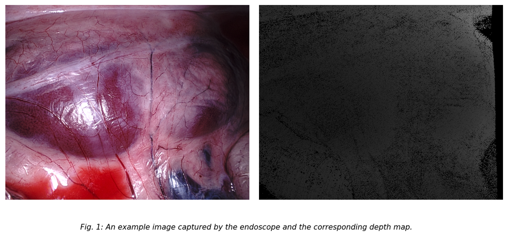

```
Cobertura GT: 78.4 %
Rango Z: [ 35.1 , 176.3 ] mm
```

```python
import zipfile, io
import numpy as np
import cv2
import tifffile
import matplotlib.pyplot as plt
from pathlib import Path

SCARED_DIR = Path('E:/scared_raw')
zip_path   = SCARED_DIR / 'dataset_1.zip'

with zipfile.ZipFile(zip_path) as zf:
    buf     = np.frombuffer(zf.read('dataset_1/keyframe_1/Left_Image.png'), np.uint8)
    img_rgb = cv2.cvtColor(cv2.imdecode(buf, cv2.IMREAD_COLOR), cv2.COLOR_BGR2RGB)
    with zf.open('dataset_1/keyframe_1/left_depth_map.tiff') as f:
        raw = tifffile.imread(io.BytesIO(f.read()))

depth_z = raw[..., 2].astype('float32')
valid   = depth_z > 0
z_min, z_max = depth_z[valid].min(), depth_z[valid].max()

# Normalizar Z a [0, 255]; zonas sin GT quedan en negro (0)
depth_gray = np.zeros_like(depth_z)
depth_gray[valid] = 255.0 * (depth_z[valid] - z_min) / (z_max - z_min)
depth_gray = depth_gray.astype('uint8')

fig, axes = plt.subplots(1, 2, figsize=(12, 5),
                         gridspec_kw={'wspace': 0.04})
axes[0].imshow(img_rgb)
axes[0].axis('off')
axes[1].imshow(depth_gray, cmap='gray', vmin=0, vmax=255)
axes[1].axis('off')
fig.text(
    0.5, 0.02,
    'Fig. 1: An example image captured by the endoscope and the corresponding depth map.',
    ha='center', fontsize=10, style='italic'
)
plt.savefig('../outcomes/eda_outputs/12_figura_paper.png',
            dpi=150, bbox_inches='tight', facecolor='white')
plt.show()
print('Cobertura GT:', round(valid.mean() * 100, 1), '%')
print('Rango Z: [', round(z_min, 1), ',', round(z_max, 1), '] mm')
```

## Agradecimientos

El Equipo 52 agradece la orientacion y asesoria tecnica del **Dr. Gilberto Ochoa Ruiz** y del **Dr. Ricardo Espinosa Loera** (Universite de Lorraine), cuyas contribuciones al campo de la vision por computadora y el procesamiento de imagenes medicas enriquecieron el diseno metodologico de este proyecto.